# Analisis Korelasi dan Regresi Linear Sederhana Antara Frekuensi Penyewaan Terhadap Total Pembayaran Pelanggan

Nama: Adyannisa Maheswari Widyaningrum | NIM: M0724017 | Kelas: F

26 May 2026

# 1 Pendahuluan

## 1.1 Latar Belakang

Memahami pola perilaku konsumen merupakan elemen krusial dalam pengambilan keputusan strategis pada industri penyewaan film. Salah satu metrik terpenting dalam mengevaluasi nilai pelanggan adalah frekuensi transaksi (seberapa sering mereka menyewa) dan kontribusi moneter (total pembayaran yang dihasilkan). Namun, sejauh mana frekuensi penyewaan film oleh seorang pelanggan dapat menjelaskan variansi dari total pembayaran yang ia hasilkan?

Untuk menjawab pertanyaan tersebut secara kuantitatif, analisis korelasi dan regresi linear sederhana digunakan sebagai kerangka metodologi. Korelasi akan mengukur derajat keeratan hubungan linear antara kedua variabel tersebut, sementara regresi linear sederhana akan memodelkan persamaan matematis untuk melihat seberapa besar prediksi perubahan total pendapatan akibat setiap penambahan satu kali frekuensi penyewaan.

Basis data Sakila dipilih sebagai sumber data utama karena menyediakan rekam jejak transaksi penyewaan (rental) dan pembayaran (payment) yang sangat kaya dan terstruktur. Melalui pemodelan statistik pada dataset operasional ini, diharapkan dapat dihasilkan insight yang tidak hanya informatif secara akademis, tetapi juga bernilai praktis bagi optimalisasi pendapatan bisnis penyewaan.

## 1.2 Rumusan Masalah

1. Apakah terdapat hubungan yang signifikan antara frekuensi penyewaan dan total pembayaran per pelanggan?
2. Seberapa kuat hubungan korelasi antara kedua variabel tersebut?
3. Bagaimana model regresi linear yang menggambarkan hubungan frekuensi penyewaan terhadap total pembayaran?
4. Seberapa baik model regresi tersebut dalam menjelaskan variasi total pembayaran pelanggan?

## 1.3 Tujuan

1. Menghitung dan menginterpretasikan koefisien korelasi Pearson antara frekuensi penyewaan dan total pembayaran per pelanggan.
2. Membangun model regresi linear sederhana dengan frekuensi penyewaan sebagai prediktor.
3. Menguji sebarapa baik model regresi yang dibangun dengan melihat nilai R-Squared.

## 1.4 Definisi Variabel

| Variabel | Nama | Tipe | Sumber Tabel | Keterangan |
| --- | --- | --- | --- | --- |
| $X$ | `total_rental` | Independen (Prediktor) | `rental` | Jumlah transaksi penyewaan per pelanggan |
| $Y$ | `total_payment` | Dependen (Respons) | `payment` | Total nilai pembayaran (USD) per pelanggan |

**Unit analisis:** Pelanggan (*customer*) — setiap baris data merepresentasikan satu pelanggan.

# 2 Persiapan Data

## 2.1 Load Library

```r
library(DBI)
library(odbc)
library(dplyr)
library(ggplot2)
library(scales)
library(knitr)
library(kableExtra)
library(broom)
library(lmtest)
library(nortest)
library(gridExtra)
```

## 2.2 Koneksi dan Pengambilan Data

Koneksi ke database, eksekusi query SQL, dan penutupan koneksi dilakukan dalam satu chunk agar pointer koneksi tidak menjadi tidak valid (*external pointer is not valid*).

```r
con2 <- DBI::dbConnect(
  odbc::odbc(),
  Driver   = "MySQL ODBC 8.0 ANSI Driver",
  Server   = "127.0.0.1",
  Database = "sakila",
  UID      = "root",
  PWD      = "12Thicato$",
  Port     = 3306
)

# Agregasi per pelanggan: total rental dan total payment
query <- "
  WITH rental_agg AS (
      SELECT
          customer_id,
          COUNT(rental_id) AS total_rental
      FROM rental
      GROUP BY customer_id
  ),
  payment_agg AS (
      SELECT
          customer_id,
          SUM(amount) AS total_payment,
          ROUND(AVG(amount), 2) AS avg_payment_per_transaksi,
          COUNT(payment_id) AS jumlah_pembayaran
      FROM payment
      GROUP BY customer_id
  )

  SELECT
      c.customer_id,
      CONCAT(c.first_name, ' ', c.last_name) AS nama_pelanggan,
      c.active,
      co.country,
      r.total_rental,
      p.total_payment,
      p.avg_payment_per_transaksi,
      p.jumlah_pembayaran
  FROM customer c
  JOIN rental_agg r ON c.customer_id = r.customer_id
  JOIN payment_agg p ON c.customer_id = p.customer_id
  JOIN address a ON c.address_id = a.address_id
  JOIN city ci ON a.city_id = ci.city_id
  JOIN country co ON ci.country_id = co.country_id
  WHERE r.total_rental > 0 AND p.total_payment > 0
  ORDER BY p.total_payment DESC
"

df_raw <- dbGetQuery(con2, query)
dbDisconnect(con2)

cat(paste("Koneksi ditutup.\nTotal pelanggan dalam dataset:", nrow(df_raw), "\n"))
```

```
## Koneksi ditutup.
## Total pelanggan dalam dataset: 599
```

**Interpretasi Pengambilan Data:** Pada tahap ini, dilakukan ekstraksi dan persiapan data dengan menarik informasi dari database Sakila langsung ke dalam environment R. Melalui skrip SQL tersebut, sistem menggabungkan berbagai tabel untuk merangkum aktivitas setiap pelanggan seperti menghitung total frekuensi menyewa dan total pembayaran, serta menyaring pelanggan yang benar-benar aktif bertransaksi. Setelah data berhasil ditarik dan disimpan sebagai dataframe bernama df_raw, koneksi ke database langsung diputus untuk menjaga keamanan dan performa memori.

Output yang muncul mengonfirmasi bahwa proses ini berjalan lancar dan berhasil mengumpulkan sampel sebanyak 599 pelanggan unik. Kumpulan data inilah yang nantinya siap digunakan untuk analisis korelasi dan regresi linear.

## 2.3 Pembersihan Data

```r
# ── Paksa konversi tipe data ke numeric terlebih dahulu ───────────
# Kolom dari MySQL kadang masuk sebagai character/integer64
# yang menyebabkan NaN saat operasi aritmatika
df_raw <- df_raw %>%
  mutate(
    total_rental  = as.numeric(total_rental),
    total_payment = as.numeric(total_payment),
    avg_payment_per_transaksi = as.numeric(avg_payment_per_transaksi),
    jumlah_pembayaran         = as.numeric(jumlah_pembayaran)
  )

# ── Sebelum cleaning ──────────────────────────────────────────────
cat("=== Kondisi Data Sebelum Cleaning ===\n")
```

```
## === Kondisi Data Sebelum Cleaning ===
```

```r
cat("Jumlah baris       :", nrow(df_raw), "\n")
```

```
## Jumlah baris       : 599
```

```r
cat("NA  total_rental   :", sum(is.na(df_raw$total_rental)), "\n")
```

```
## NA  total_rental   : 0
```

```r
cat("NaN total_rental   :", sum(is.nan(df_raw$total_rental)), "\n")
```

```
## NaN total_rental   : 0
```

```r
cat("Inf total_rental   :", sum(!is.finite(df_raw$total_rental) &
                                 !is.nan(df_raw$total_rental) &
                                 !is.na(df_raw$total_rental)), "\n")
```

```
## Inf total_rental   : 0
```

```r
cat("NA  total_payment  :", sum(is.na(df_raw$total_payment)), "\n")
```

```
## NA  total_payment  : 0
```

```r
cat("NaN total_payment  :", sum(is.nan(df_raw$total_payment)), "\n")
```

```
## NaN total_payment  : 0
```

```r
cat("Inf total_payment  :", sum(!is.finite(df_raw$total_payment) &
                                 !is.nan(df_raw$total_payment) &
                                 !is.na(df_raw$total_payment)), "\n")
```

```
## Inf total_payment  : 0
```

```r
cat("Duplikat           :", sum(duplicated(df_raw)), "\n\n")
```

```
## Duplikat           : 0
```

```r
# ── Cleaning ──────────────────────────────────────────────────────
df_raw <- df_raw %>%
  filter(
    is.finite(total_rental),
    is.finite(total_payment),
    total_rental  > 0,
    total_payment > 0
  ) %>%
  distinct(customer_id, .keep_all = TRUE)

# ── Setelah cleaning ──────────────────────────────────────────────
cat("=== Kondisi Data Setelah Cleaning ===\n")
```

```
## === Kondisi Data Setelah Cleaning ===
```

```r
cat("Jumlah baris       :", nrow(df_raw), "\n")
```

```
## Jumlah baris       : 599
```

```r
cat("NA/NaN/Inf rental  :", sum(!is.finite(df_raw$total_rental)), "\n")
```

```
## NA/NaN/Inf rental  : 0
```

```r
cat("NA/NaN/Inf payment :", sum(!is.finite(df_raw$total_payment)), "\n")
```

```
## NA/NaN/Inf payment : 0
```

```r
cat("Duplikat           :", sum(duplicated(df_raw)), "\n")
```

```
## Duplikat           : 0
```

```r
cat("\n✅ Data siap dianalisis.\n")
```

```
##
## ✅ Data siap dianalisis.
```

**Interpretasi Pembersihan Data:** Tahap selanjutnya adalah preprocessing data dengan melihat dan melakukan penanganan mising value serta duplikat. Berdasarkan hasil output, data ini tidak memiliki misiing value serta duplikat sehinga sudah siap untuk dianalisis.

# 3 Deskripsi Data

## 3.1 Struktur Data

```r
str(df_raw)
```

```
## 'data.frame':    599 obs. of  8 variables:
##  $ customer_id              : int  526 148 144 137 178 459 469 468 236 181 ...
##  $ nama_pelanggan           : chr  "KARL SEAL" "ELEANOR HUNT" "CLARA SHAW" "RHONDA KENNEDY" ...
##  $ active                   : int  1 1 1 1 1 1 1 1 1 1 ...
##  $ country                  : chr  "United States" "Réunion" "Belarus" "Netherlands" ...
##  $ total_rental             : num  45 46 42 39 39 38 40 39 42 34 ...
##  $ total_payment            : num  222 217 196 195 195 ...
##  $ avg_payment_per_transaksi: num  4.92 4.71 4.66 4.99 4.99 4.91 4.44 4.5 4.18 5.14 ...
##  $ jumlah_pembayaran        : num  45 46 42 39 39 38 40 39 42 34 ...
```

**Interpretasi struktur Data:** Langkah inspeksi ini merupakan tahap yang sangat penting guna memastikan tidak ada kesalahan format (misalnya, variabel angka yang tidak sengaja terbaca sebagai teks) sebelum lanjut ke proses analisis korelasi dan regresi

## 3.2 Sampel Data

```r
head(df_raw, 10) %>%
  kable(caption = "Tabel 1. Sampel 10 Data Pelanggan Teratas (berdasarkan total pembayaran)") %>%
  kable_styling(bootstrap_options = c("striped","hover","condensed"),
                full_width = TRUE, font_size = 12)
```

Tabel 1. Sampel 10 Data Pelanggan Teratas (berdasarkan total pembayaran)

| customer_id | nama_pelanggan | active | country | total_rental | total_payment | avg_payment_per_transaksi | jumlah_pembayaran |
| --- | --- | --- | --- | --- | --- | --- | --- |
| 526 | KARL SEAL | 1 | United States | 45 | 221.55 | 4.92 | 45 |
| 148 | ELEANOR HUNT | 1 | Réunion | 46 | 216.54 | 4.71 | 46 |
| 144 | CLARA SHAW | 1 | Belarus | 42 | 195.58 | 4.66 | 42 |
| 137 | RHONDA KENNEDY | 1 | Netherlands | 39 | 194.61 | 4.99 | 39 |
| 178 | MARION SNYDER | 1 | Brazil | 39 | 194.61 | 4.99 | 39 |
| 459 | TOMMY COLLAZO | 1 | Iran | 38 | 186.62 | 4.91 | 38 |
| 469 | WESLEY BULL | 1 | Spain | 40 | 177.60 | 4.44 | 40 |
| 468 | TIM CARY | 1 | India | 39 | 175.61 | 4.50 | 39 |
| 236 | MARCIA DEAN | 1 | Philippines | 42 | 175.58 | 4.18 | 42 |
| 181 | ANA BRADLEY | 1 | United States | 34 | 174.66 | 5.14 | 34 |

## 3.3 Statistik Deskriptif

```r
desc_tabel <- data.frame(
  Statistik = c("Minimum", "Q1 (25%)", "Median", "Mean",
                "Q3 (75%)", "Maksimum", "Std. Deviasi", "Koef. Variasi (%)"),
  `Total Rental X` = c(
    min(df_raw$total_rental,                    na.rm = TRUE),
    quantile(df_raw$total_rental, 0.25,         na.rm = TRUE),
    median(df_raw$total_rental,                 na.rm = TRUE),
    round(mean(df_raw$total_rental,             na.rm = TRUE), 2),
    quantile(df_raw$total_rental, 0.75,         na.rm = TRUE),
    max(df_raw$total_rental,                    na.rm = TRUE),
    round(sd(df_raw$total_rental,               na.rm = TRUE), 2),
    round(sd(df_raw$total_rental,               na.rm = TRUE) /
          mean(df_raw$total_rental,             na.rm = TRUE) * 100, 2)
  ),
  `Total Payment USD Y` = c(
    round(min(df_raw$total_payment,             na.rm = TRUE), 2),
    round(quantile(df_raw$total_payment, 0.25,  na.rm = TRUE), 2),
    round(median(df_raw$total_payment,          na.rm = TRUE), 2),
    round(mean(df_raw$total_payment,            na.rm = TRUE), 2),
    round(quantile(df_raw$total_payment, 0.75,  na.rm = TRUE), 2),
    round(max(df_raw$total_payment,             na.rm = TRUE), 2),
    round(sd(df_raw$total_payment,              na.rm = TRUE), 2),
    round(sd(df_raw$total_payment,              na.rm = TRUE) /
          mean(df_raw$total_payment,            na.rm = TRUE) * 100, 2)
  )
)

desc_tabel %>%
  kable(
    caption     = "Tabel 2. Statistik Deskriptif Variabel X dan Y",
    col.names   = c("Statistik", "Total Rental (X)", "Total Payment USD (Y)")
  ) %>%
  kable_styling(bootstrap_options = c("striped","hover"), full_width = FALSE) %>%
  row_spec(4, bold = TRUE, background = "#eaf4fb")
```

Tabel 2. Statistik Deskriptif Variabel X dan Y

| Statistik | Total Rental (X) | Total Payment USD (Y) |
| --- | --- | --- |
| Minimum | 12.00 | 50.85 |
| Q1 (25%) | 23.00 | 94.78 |
| Median | 26.00 | 110.73 |
| Mean | 26.78 | 112.53 |
| Q3 (75%) | 30.00 | 128.70 |
| Maksimum | 46.00 | 221.55 |
| Std. Deviasi | 5.11 | 25.37 |
| Koef. Variasi (%) | 19.08 | 22.54 |

**Interpretasi Statistik Deskriptif:** hasil statistik deskriptif menunjukkan karakteristik data yang representatif dan berdistribusi dengan baik. Pada variabel Total Rental (X), rata-rata (mean) frekuensi pelanggan menyewa film adalah sebanyak 26,78 kali, dengan nilai tengah (median) sebesar 26. Kedekatan antara nilai mean dan median ini mengindikasikan bahwa distribusi data cenderung simetris. Tingkat keragaman data juga tergolong rendah dengan Koefisien Variasi sebesar 19,08%, di mana rentang transaksi berada antara 12 hingga 46 kali penyewaan.

# 4 Exploratory Data Analysis (EDA)

## 4.1 Distribusi Variabel X dan Y

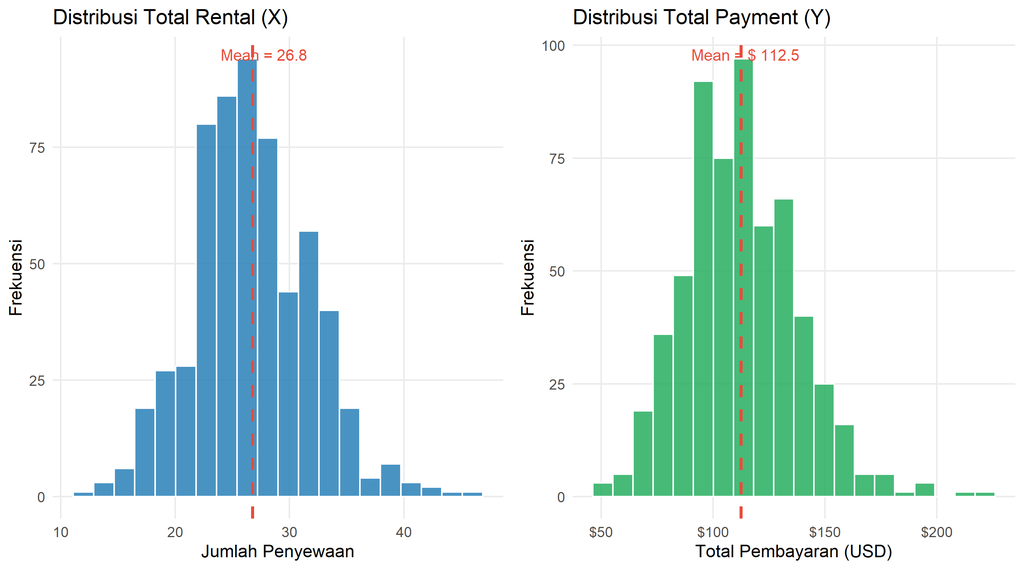

Gambar 1. Distribusi Frekuensi Total Rental (kiri) dan Total Payment (kanan)

```r
p1 <- ggplot(df_raw, aes(x = total_rental)) +
  geom_histogram(bins = 20, fill = "#2980b9", color = "white", alpha = 0.85) +
  geom_vline(xintercept = mean(df_raw$total_rental),
             color = "#e74c3c", linetype = "dashed", linewidth = 1) +
  annotate("text",
           x     = mean(df_raw$total_rental) + 1,
           y     = Inf, vjust = 2,
           label = paste("Mean =", round(mean(df_raw$total_rental), 1)),
           color = "#e74c3c", size = 3.5) +
  labs(title = "Distribusi Total Rental (X)",
       x = "Jumlah Penyewaan", y = "Frekuensi") +
  theme_minimal(base_size = 11) +
  theme(panel.grid.minor = element_blank())

p2 <- ggplot(df_raw, aes(x = total_payment)) +
  geom_histogram(bins = 20, fill = "#27ae60", color = "white", alpha = 0.85) +
  geom_vline(xintercept = mean(df_raw$total_payment),
             color = "#e74c3c", linetype = "dashed", linewidth = 1) +
  annotate("text",
           x     = mean(df_raw$total_payment) + 2,
           y     = Inf, vjust = 2,
           label = paste("Mean = $", round(mean(df_raw$total_payment), 1)),
           color = "#e74c3c", size = 3.5) +
  scale_x_continuous(labels = dollar) +
  labs(title = "Distribusi Total Payment (Y)",
       x = "Total Pembayaran (USD)", y = "Frekuensi") +
  theme_minimal(base_size = 11) +
  theme(panel.grid.minor = element_blank())

grid.arrange(p1, p2, ncol = 2)
```

**Interpretasi:** Histogram memperlihatkan bentuk distribusi masing-masing variabel total rental (x) dan total paymenr (Y). Pada grafik Distribusi Total Rental (X), terlihat bahwa frekuensi penyewaan memusat di tengah, tepatnya di sekitar garis putus-putus merah yang menandakan nilai rata-rata (mean) sebesar 26,8 kali. Pola serupa juga terlihat pada grafik Distribusi Total Payment (Y), di mana akumulasi pendapatan tertinggi dari pelanggan terpusat di sekitar nilai rata-rata $112,5.

Kedua histogram tersebut membentuk pola kurva yang menyerupai lonceng. Bentuk ini secara visual mengonfirmasi temuan pada statistik deskriptif sebelumnya, yaitu bahwa data terdistribusi secara simetris dan mendekati distribusi normal.

## 4.2 Scatter Plot Hubungan X dan Y

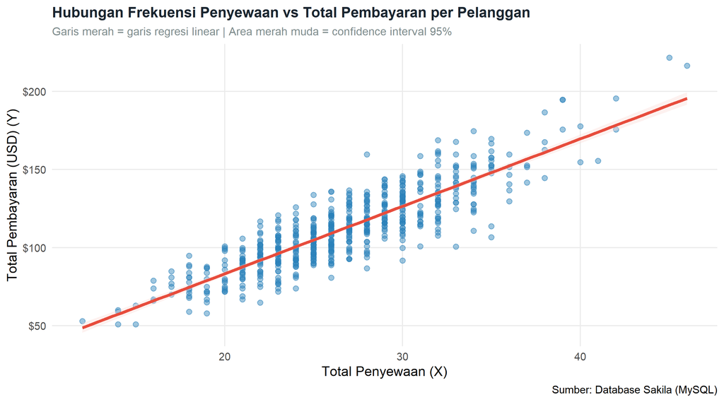

Gambar 2. Scatter Plot Total Rental vs Total Payment per Pelanggan

```r
ggplot(df_raw, aes(x = total_rental, y = total_payment)) +
  geom_point(color = "#2980b9", alpha = 0.45, size = 2) +
  geom_smooth(method = "lm", color = "#e74c3c", se = TRUE,
              fill = "#fadbd8", linewidth = 1.3) +
  scale_y_continuous(labels = dollar) +
  labs(
    title    = "Hubungan Frekuensi Penyewaan vs Total Pembayaran per Pelanggan",
    subtitle = "Garis merah = garis regresi linear | Area merah muda = confidence interval 95%",
    x        = "Total Penyewaan (X)",
    y        = "Total Pembayaran (USD) (Y)",
    caption  = "Sumber: Database Sakila (MySQL)"
  ) +
  theme_minimal(base_size = 12) +
  theme(
    plot.title       = element_text(face = "bold", size = 13, color = "#1a252f"),
    plot.subtitle    = element_text(color = "#7f8c8d", size = 10),
    panel.grid.minor = element_blank()
  )
```

**Interpretasi Scatter Plot:** Pola sebaran titik data memberikan gambaran awal arah dan bentuk hubungan antara X dan Y. Titik-titik data secara konsisten menunjukkan tren yang menanjak dari kiri bawah ke kanan atas. Hal ini mengindikasikan adanya korelasi positif yang kuat; artinya, semakin tinggi frekuensi penyewaan seorang pelanggan (Sumbu X), maka semakin besar pula total pembayaran yang mereka berikan kepada perusahaan (Sumbu Y).

Dari segi bentuk hubungan, sebaran titik tersebut mengelompok dan mengikuti sebuah jalur garis lurus, yang memvalidasi bahwa hubungan kedua variabel bersifat linear.

# 5 Uji Korelasi Pearson

## 5.1 Dasar Teori

**Korelasi Pearson** mengukur kekuatan dan arah hubungan **linear** antara dua variabel kontinu. Koefisien korelasi Pearson ($r$) didefinisikan sebagai:

$$r =
\frac{\displaystyle\sum_{i=1}^{n}(X_i - \bar{X})(Y_i -
\bar{Y})}{\sqrt{\displaystyle\sum_{i=1}^{n}(X_i - \bar{X})^2 \cdot
\sum_{i=1}^{n}(Y_i - \bar{Y})^2}}$$

Nilai $r$ berkisar antara $-1$ hingga $+1$:

| Nilai $\|r\|$ | Interpretasi |
| --- | --- |
| $0{,}00 - 0{,}19$ | Sangat lemah |
| $0{,}20 - 0{,}39$ | Lemah |
| $0{,}40 - 0{,}59$ | Sedang |
| $0{,}60 - 0{,}79$ | Kuat |
| $0{,}80 - 1{,}00$ | Sangat kuat |

**Hipotesis uji:**
$$H_0:
\rho = 0 \quad \text{(tidak ada korelasi linear)}$$
$$H_1: \rho \neq 0 \quad \text{(terdapat korelasi
linear)}$$

**Statistik uji:**
$$t =
\frac{r\sqrt{n-2}}{\sqrt{1-r^2}}, \quad df = n - 2$$

Tolak $H_0$ jika $p\text{-value} < \alpha = 0{,}05$.

## 5.2 Hasil Uji Korelasi

```r
cor_test <- cor.test(df_raw$total_rental, df_raw$total_payment,
                     method = "pearson")

cat("=== Hasil Uji Korelasi Pearson ===\n")
```

```
## === Hasil Uji Korelasi Pearson ===
```

```r
cat(paste("Koefisien Korelasi (r)     :", round(cor_test$estimate, 4), "\n"))
```

```
## Koefisien Korelasi (r)     : 0.8707
```

```r
cat(paste("Koefisien Determinasi (r^2):", round(cor_test$estimate^2, 4), "\n"))
```

```
## Koefisien Determinasi (r^2): 0.7581
```

```r
cat(paste("Statistik t                :", round(cor_test$statistic, 4), "\n"))
```

```
## Statistik t                : 43.2494
```

```r
cat(paste("Derajat Bebas (df)         :", cor_test$parameter, "\n"))
```

```
## Derajat Bebas (df)         : 597
```

```r
cat(paste("p-value                    :", format(cor_test$p.value, scientific = TRUE), "\n"))
```

```
## p-value                    : 4.099419e-186
```

```r
cat(paste("Confidence Interval 95%    :",
          round(cor_test$conf.int[1], 4), "-", round(cor_test$conf.int[2], 4), "\n"))
```

```
## Confidence Interval 95%    : 0.8498 - 0.8888
```

```r
r_val     <- abs(cor_test$estimate)
kekuatan  <- ifelse(r_val >= 0.80, "SANGAT KUAT",
             ifelse(r_val >= 0.60, "KUAT",
             ifelse(r_val >= 0.40, "SEDANG",
             ifelse(r_val >= 0.20, "LEMAH", "SANGAT LEMAH"))))
arah      <- ifelse(cor_test$estimate > 0, "POSITIF", "NEGATIF")

cat(paste("\nKategori kekuatan korelasi :", kekuatan, "\n"))
```

```
##
## Kategori kekuatan korelasi : SANGAT KUAT
```

```r
cat(paste("Arah korelasi              :", arah, "\n"))
```

```
## Arah korelasi              : POSITIF
```

```r
if (cor_test$p.value < 0.05) {
  cat("Kesimpulan: Tolak H0 — Korelasi SIGNIFIKAN secara statistik (p < 0.05)\n")
} else {
  cat("Kesimpulan: Gagal tolak H0 — Korelasi TIDAK SIGNIFIKAN (p >= 0.05)\n")
}
```

```
## Kesimpulan: Tolak H0 — Korelasi SIGNIFIKAN secara statistik (p < 0.05)
```

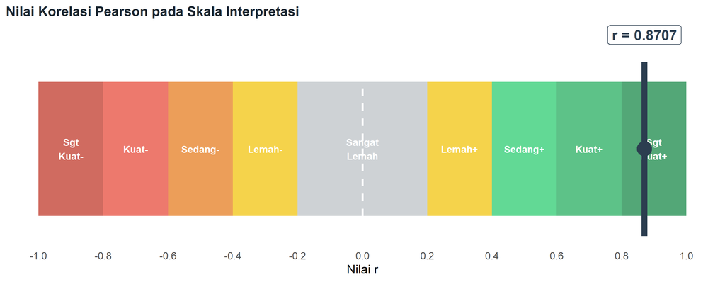

Gambar 3. Posisi Nilai r pada Skala Interpretasi Korelasi

```r
r_value <- round(cor_test$estimate, 4)

zones <- data.frame(
  xmin  = c(-1, -0.8, -0.6, -0.4, -0.2, 0.2, 0.4, 0.6, 0.8),
  xmax  = c(-0.8, -0.6, -0.4, -0.2, 0.2, 0.4, 0.6, 0.8, 1),
  fill  = c("#c0392b","#e74c3c","#e67e22","#f1c40f","#bdc3c7",
            "#f1c40f","#2ecc71","#27ae60","#1a8a4a"),
  label = c("Sgt\nKuat-","Kuat-","Sedang-","Lemah-","Sangat\nLemah",
            "Lemah+","Sedang+","Kuat+","Sgt\nKuat+")
)

ggplot() +
  geom_rect(data = zones,
            aes(xmin = xmin, xmax = xmax, ymin = 0, ymax = 1, fill = fill),
            alpha = 0.75) +
  scale_fill_identity() +
  geom_text(data = zones,
            aes(x = (xmin + xmax) / 2, y = 0.5, label = label),
            color = "white", fontface = "bold", size = 3) +
  geom_segment(aes(x = r_value, xend = r_value, y = -0.15, yend = 1.15),
               color = "#2c3e50", linewidth = 2.5) +
  geom_point(aes(x = r_value, y = 0.5),
             color = "#2c3e50", size = 6) +
  annotate("label", x = r_value, y = 1.35,
           label = paste("r =", r_value),
           fontface = "bold", size = 4.5, color = "#2c3e50",
           fill = "white", label.size = 0.5) +
  geom_vline(xintercept = 0, color = "white",
             linetype = "dashed", linewidth = 0.8) +
  scale_x_continuous(breaks = seq(-1, 1, 0.2), limits = c(-1, 1)) +
  labs(
    title = "Nilai Korelasi Pearson pada Skala Interpretasi",
    x     = "Nilai r",
    y     = NULL
  ) +
  theme_minimal(base_size = 11) +
  theme(
    axis.text.y      = element_blank(),
    axis.ticks.y     = element_blank(),
    panel.grid       = element_blank(),
    plot.title       = element_text(face = "bold", color = "#1a252f", size = 12)
  )
```

**Interpretasi Korelasi:** Nilai $r = 0.8707$ menunjukkan adanya hubungan linear **SANGAT KUAT** berpola **POSITIF** antara frekuensi penyewaan dan total pembayaran pelanggan. Dengan $r^2 = 0.7581$, sekitar **75.8%** variasi total pembayaran dapat dijelaskan oleh variasi frekuensi penyewaan saja. Hubungan ini terbukti **signifikan secara statistik** ($p < 0{,}05$).

# 6 Analisis Regresi Linear Sederhana

## 6.1 Dasar Teori

**Model Regresi Linear Sederhana** menggambarkan hubungan antara satu variabel independen ($X$) dan satu variabel dependen ($Y$) dalam bentuk garis lurus:

$$\hat{Y} = \beta_0 + \beta_1 X +
\varepsilon$$

di mana:

- $\hat{Y}$ = prediksi total pembayaran (USD)
- $\beta_0$ = intersep (nilai $Y$ ketika $X = 0$)
- $\beta_1$ = koefisien regresi (perubahan $Y$ untuk setiap kenaikan 1 unit $X$)
- $\varepsilon \sim N(0,\, \sigma^2)$ = error/residual

**Estimasi parameter OLS (*Ordinary Least Squares*):**

$$\hat{\beta}_1 =
\frac{\displaystyle\sum_{i=1}^{n}(X_i - \bar{X})(Y_i -
\bar{Y})}{\displaystyle\sum_{i=1}^{n}(X_i - \bar{X})^2}, \qquad
\hat{\beta}_0 = \bar{Y} - \hat{\beta}_1\,\bar{X}$$

**Koefisien Determinasi ($R^2$):**

$$R^2 = 1 - \frac{SS_{res}}{SS_{tot}} = 1
- \frac{\displaystyle\sum_{i=1}^{n}(\hat{Y}_i -
Y_i)^2}{\displaystyle\sum_{i=1}^{n}(Y_i - \bar{Y})^2}$$

## 6.2 Membangun Model

```r
# Ambil hanya baris yang benar-benar complete (lapisan pengaman final)
df_model <- df_raw[complete.cases(df_raw[, c("total_rental", "total_payment")]), ]
df_model <- df_model[is.finite(df_model$total_rental) &
                     is.finite(df_model$total_payment), ]

cat("Observasi masuk model:", nrow(df_model), "\n")
```

```
## Observasi masuk model: 599
```

```r
cat("NA/NaN/Inf tersisa   :", sum(!is.finite(df_model$total_rental)),
    "|", sum(!is.finite(df_model$total_payment)), "\n\n")
```

```
## NA/NaN/Inf tersisa   : 0 | 0
```

```r
# Bangun model dengan data yang sudah benar-benar bersih
model_reg <- lm(total_payment ~ total_rental, data = df_model)

# Tampilkan summary
summary(model_reg)
```

```
##
## Call:
## lm(formula = total_payment ~ total_rental, data = df_model)
##
## Residuals:
##     Min      1Q  Median      3Q     Max
## -41.386  -8.391  -0.074   8.431  41.936
##
## Coefficients:
##              Estimate Std. Error t value Pr(>|t|)
## (Intercept)  -3.22174    2.72462  -1.182    0.237
## total_rental  4.32164    0.09992  43.249   <2e-16 ***
## ---
## Signif. codes:  0 '***' 0.001 '**' 0.01 '*' 0.05 '.' 0.1 ' ' 1
##
## Residual standard error: 12.49 on 597 degrees of freedom
## Multiple R-squared:  0.7581, Adjusted R-squared:  0.7577
## F-statistic:  1871 on 1 and 597 DF,  p-value: < 2.2e-16
```

## 6.3 Ringkasan Koefisien

```r
tidy(model_reg) %>%
  mutate(
    term = c("Intersep (beta_0)", "Total Rental (beta_1)"),
    across(where(is.numeric), ~round(.x, 4))
  ) %>%
  rename(
    Parameter    = term,
    Estimasi     = estimate,
    `Std. Error` = std.error,
    `t-value`    = statistic,
    `p-value`    = p.value
  ) %>%
  kable(caption = "Tabel 3. Koefisien Model Regresi Linear Sederhana") %>%
  kable_styling(bootstrap_options = c("striped","hover"), full_width = FALSE) %>%
  row_spec(2, bold = TRUE, background = "#eafaf1")
```

Tabel 3. Koefisien Model Regresi Linear Sederhana

| Parameter | Estimasi | Std. Error | t-value | p-value |
| --- | --- | --- | --- | --- |
| Intersep (beta_0) | -3.2217 | 2.7246 | -1.1825 | 0.2375 |
| Total Rental (beta_1) | 4.3216 | 0.0999 | 43.2494 | 0.0000 |

```r
gof <- glance(model_reg)
b0  <- round(coef(model_reg)[1], 4)
b1  <- round(coef(model_reg)[2], 4)

cat("=== Kebaikan Model (Goodness of Fit) ===\n")
```

```
## === Kebaikan Model (Goodness of Fit) ===
```

```r
cat(paste("R-squared          :", round(gof$r.squared,     4), "\n"))
```

```
## R-squared          : 0.7581
```

```r
cat(paste("Adjusted R-squared :", round(gof$adj.r.squared, 4), "\n"))
```

```
## Adjusted R-squared : 0.7577
```

```r
cat(paste("RSE                :", round(gof$sigma,         4), "\n"))
```

```
## RSE                : 12.4874
```

```r
cat(paste("F-statistic        :", round(gof$statistic,     4), "\n"))
```

```
## F-statistic        : 1870.5103
```

```r
cat(paste("p-value (F-test)   :", format(gof$p.value, scientific = TRUE), "\n"))
```

```
## p-value (F-test)   : 4.099419e-186
```

```r
cat(paste("Jumlah observasi   :", gof$nobs, "\n"))
```

```
## Jumlah observasi   : 599
```

```r
cat(paste("\nPersamaan Regresi  : Total_Payment =", b0, "+", b1, "x Total_Rental\n"))
```

```
##
## Persamaan Regresi  : Total_Payment = -3.2217 + 4.3216 x Total_Rental
```

**Persamaan Model Regresi yang Terbentuk:**

$$\hat{Y} = -3.222 + 4.322 \cdot
X$$

**Interpretasi koefisien:**

- **Intersep ($\hat{\beta}_0 = -3.222$):** Ketika pelanggan tidak melakukan penyewaan sama sekali ($X = 0$), estimasi total pembayaran adalah $-3.222$ USD. Nilai ini merupakan konstanta baseline model.
- **Koefisien Regresi ($\hat{\beta}_1 = 4.322$):** Setiap penambahan **1 kali penyewaan**, total pembayaran pelanggan diprediksi meningkat rata-rata sebesar **$4.322$ USD**, dengan asumsi faktor lain konstan.
- **$R^2 = 0.7581$:** Model ini mampu menjelaskan **75.81%** variasi total pembayaran pelanggan.

## 6.4 Visualisasi Garis Regresi

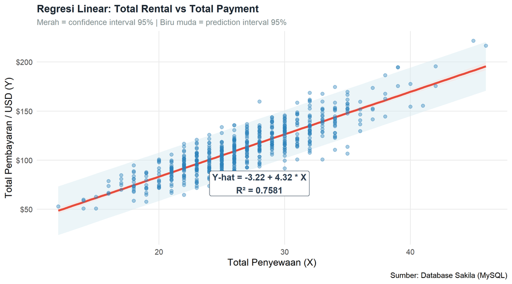

Gambar 4. Garis Regresi dengan Confidence dan Prediction Interval

```r
pred_int  <- predict(model_reg, interval = "prediction", level = 0.95)
plot_data <- df_model %>%
  mutate(lwr = pred_int[,"lwr"], upr = pred_int[,"upr"])

ggplot(plot_data, aes(x = total_rental, y = total_payment)) +
  geom_ribbon(aes(ymin = lwr, ymax = upr),
              fill = "#d5e8f0", alpha = 0.45) +
  geom_smooth(method = "lm", se = TRUE,
              color = "#e74c3c", fill = "#fadbd8",
              linewidth = 1.3, alpha = 0.4) +
  geom_point(alpha = 0.4, color = "#2980b9", size = 1.8) +
  scale_y_continuous(labels = dollar) +
  annotate("label",
           x     = quantile(df_model$total_rental, 0.6),
           y     = min(df_model$total_payment) * 1.5,
           label = paste0("Y-hat = ", round(coef(model_reg)[1], 2),
                          " + ", round(coef(model_reg)[2], 2), " * X\n",
                          "R² = ", round(gof$r.squared, 4)),
           size  = 4, color = "#2c3e50", fontface = "bold",
           fill  = "white", label.size = 0.4) +
  labs(
    title    = "Regresi Linear: Total Rental vs Total Payment",
    subtitle = "Merah = confidence interval 95% | Biru muda = prediction interval 95%",
    x        = "Total Penyewaan (X)",
    y        = "Total Pembayaran / USD (Y)",
    caption  = "Sumber: Database Sakila (MySQL)"
  ) +
  theme_minimal(base_size = 12) +
  theme(
    plot.title       = element_text(face = "bold", size = 13, color = "#1a252f"),
    plot.subtitle    = element_text(color = "#7f8c8d", size = 10),
    panel.grid.minor = element_blank()
  )
```

# 7 Kesimpulan

Berdasarkan seluruh analisis korelasi dan regresi linear sederhana menggunakan data pelanggan database Sakila, diperoleh kesimpulan sebagai berikut:

**1. Uji Korelasi Pearson** Koefisien korelasi $r = 0.8707$ menunjukkan hubungan linear **SANGAT KUAT** berpola **POSITIF** antara frekuensi penyewaan ($X$) dan total pembayaran ($Y$). Dengan $r^2 = 0.7581$, sekitar 75.8% variasi total pembayaran dijelaskan oleh frekuensi penyewaan. Korelasi ini **signifikan secara statistik** ($p < 0{,}05$).

**2. Model Regresi Linear** Model regresi yang terbentuk:
$$\hat{Y} = -3.222 + 4.322 \cdot
X$$
Setiap penambahan 1 kali penyewaan diprediksi meningkatkan total pembayaran pelanggan sebesar **$4.322**. Koefisien ini signifikan secara statistik.

**3. Kebaikan Model** Nilai $R^2 = 0.7581$ menunjukkan model mampu menjelaskan **75.81%** variasi total pembayaran. Sisa variasi dijelaskan oleh faktor lain yang tidak tercakup dalam model ini (misalnya durasi sewa, kategori film, atau tarif film).

**4. Implikasi Bisnis** Frekuensi penyewaan terbukti menjadi prediktor yang signifikan bagi total pendapatan per pelanggan. Strategi yang mendorong pelanggan menyewa lebih sering, seperti program loyalitas, bundling, atau rekomendasi film yang dipersonalisasi akan berpotensi langsung meningkatkan total pendapatan bisnis.

# 8 Referensi

- Montgomery, D.C., Peck, E.A., & Vining, G.G. (2021). *Introduction to Linear Regression Analysis* (6th ed.). Wiley.
- MySQL. (2023). *Sakila Sample Database*. https://dev.mysql.com/doc/sakila/en/
- Pearson, K. (1895). Notes on regression and inheritance in the case of two parents. *Proceedings of the Royal Society of London*, 58, 240–242.
- Breusch, T.S., & Pagan, A.R. (1979). A simple test for heteroscedasticity and related problems. *Econometrica*, 47(5), 1287–1294.
- Conover, W.J. (1999). *Practical Nonparametric Statistics* (3rd ed.). Wiley.